# Er musste das Wissen aufheben

van Fraassen on the priority of the manifest image

Hans Halvorson

Princeton University

2026-06-09

# Mission accomplished?

## Mission accomplished?

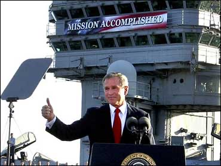

## What was Bas’ mission?

Not the doctrines — constructive empiricism, the modal interpretation, the semantic view, voluntarist epistemology.

Those are the *outputs*. The mission was something else:

to make a space in which human beings can do science as human beings.

## The big mission: a space of reasons

Harald Høffding helped create the intellectual culture in which Niels Bohr was possible.

This is Bas’s mission too: a space of reasons — to borrow Sellars’ own term — in which human beings can flourish: intellectually, creatively, scientifically.

> I do not think we need new theories in philosophy. But … we must change, or change back, the way we do philosophy — in aid of an authentic, engaged project, conscious of its own limits.

## Outline

1. Sellars’ problematic
2. van Fraassen: challenge accepted
3. The Danish road
4. Er musste das Wissen aufheben

# Sellars’ problematic

## Pittsburgh, circa 1963

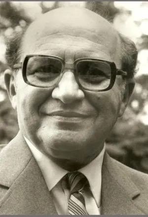

Grünbaum

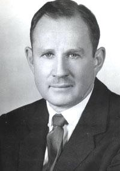

Sellars

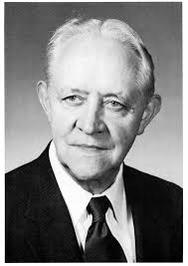

Kockelmans

*the problematic of a philosophical career is set*

## Sellars “Philosophy and the Scientific Image of Man”

> The philosopher, then, is confronted by two conceptions … of man-in-the-world and he cannot shirk the attempt to see how they fall together in one stereoscopic view.

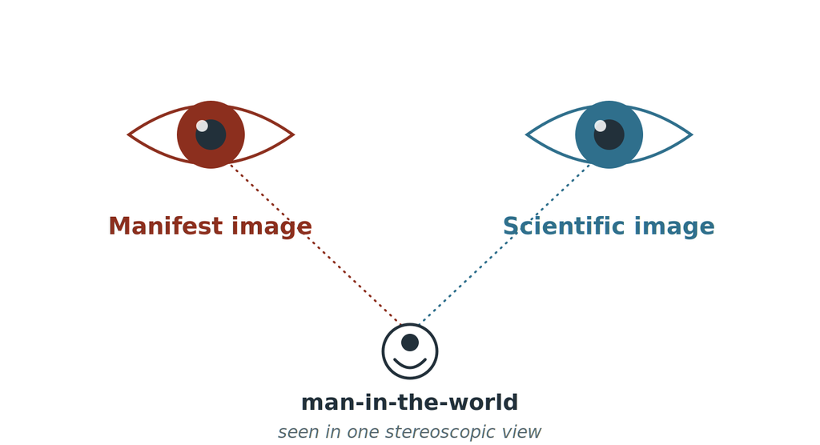

## The two images, felt

I cannot help experiencing time as flowing — the present as real, the future as open.

Special relativity appears to have no place for either: no absolute present, no flow.

Putnam: past and future are as real as the present. The manifest “now” — an illusion?

## Sellars “Philosophy and the Scientific Image of Man”

> I have characterized the manifest image of man-in-the-world as the framework in which man encountered himself.

> What I have referred to as the ‘scientific’ image of man-in-the-world and contrasted with the ‘manifest’ image, might better be called the ‘postulational’ or ‘theoretical’ image.

## The Perennial Philosophy

> … the manifest image endorsed as real, and its outline taken to be the large-scale map of reality to which science brings a needle-point of detail and an elaborate technique of map-reading.

> I *am* implying that the perennial philosophy is analogous to what one gets when one looks through a stereoscope with one eye dominating.

## Against the Perennial Philosophy

> I seem, therefore, to be saying … that man is not the sort of thing he conceives himself to be; that his existence is in some measure built around error. … One thinks, for example, of Spinoza, who contrasted man as he falsely conceives himself to be with man as he discovers himself to be in the scientific enterprise.

## Sellars’ Ambiguity

> … the very fact that I use the analogy of stereoscopic vision implies that as I see it the manifest image is not overwhelmed.

> … the first, which, like a child, says ‘both’, is ruled out by a principle which I am not defending in this chapter.

Not overwhelmed — yet ‘both’ is ruled out. Which is it?

## Closing the circle

“Let the scientific image account for **everything** — including the describer who produced it.”

One mission, many names: reduction → supervenience → grounding

Not a drop of existentialism — the self always comes second to the system.

A mission one may choose, as Bas chose another.

## Closing the circle: the programs

In physics:

**measurement problem** — remove the observer from the quantum axioms · **the Mentaculus** — the world from one probability distribution · **Lewis** — everything on the Humean mosaic · **Field** — science without numbers

In philosophy of mind:

**Quine** — epistemology naturalized · **Churchland** — the self as folk theory, ripe for elimination · **Dennett** — the first person redescribed from the third

*the same mission, on two fronts*

## Pittsburgh, 1996

McDowell elevates Sellars’ essay to the canon — and dissolves the dilemma: the space of reasons need be neither reduced nor spooky.

*The courageous move — and nearly Bas’s own.*

But then the coda: “…a naturalism of second nature.”

To invoke second nature is to promise grounding in first nature — the reduction deferred, not refused. The courage is taken back.

# van Fraassen meets the challenge

## Responses to Sellars’ problem

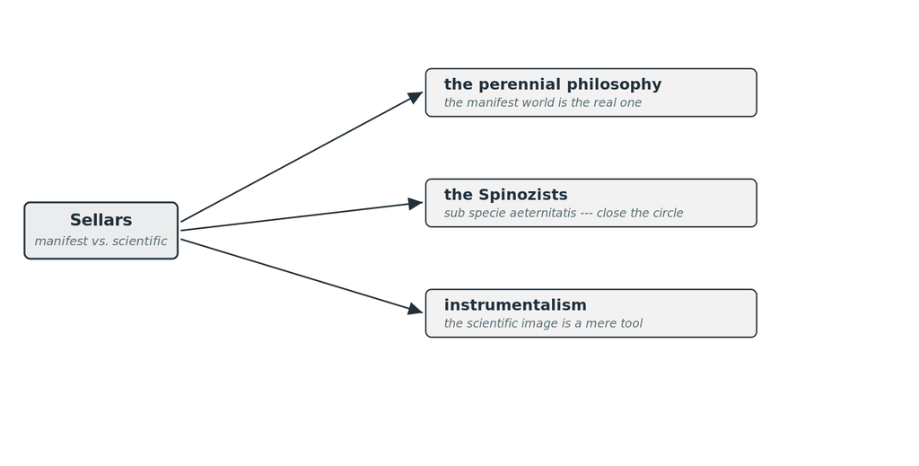

## Responses to Sellars’ problem

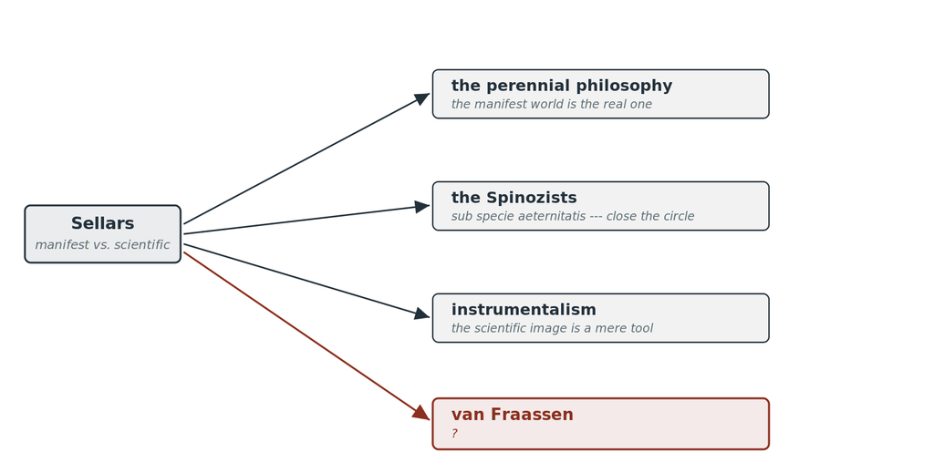

## “The Manifest Image and the Scientific Image”

> there is something much more fundamentally wrong with the entire dialectic — there are no such things as the Manifest and Scientific Images at all

> the Scientific Image is as replete with uncashed and ultimately uncashable promissory notes as the Manifest Image

## *The Empirical Stance* (2002)

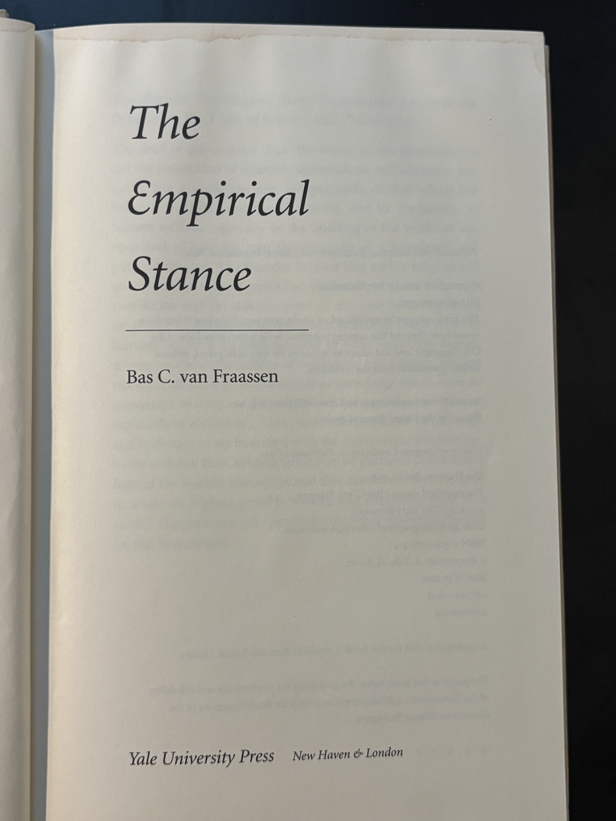

A new term: **objectifying inquiry**

not a proposition, not a theory, not a worldview, not an *image* —

it is an activity, something we *do*

Bas ventures past the static categories of analytic philosophy

## Characteristics of objectifying inquiry

It **delimits its object in advance** — the domain fixed, the parameters of relevance pre-set.

The result: a model that represents the target, with the inquirer removed from view.

*But to delimit an object is already to perform an act of objectification* — and the Danes drew the consequence.

## Inquiry without objectification

van Fraassen: *are there nonobjectifying forms of inquiry?*

> we do have concrete, recognizable instances of other cognitively significant approaches

systematic, cognitive — and not objectifying

# The Danish road

## Hegel

[figure not shown]

The most ambitious circle-closer of all: the System absorbs everything — nature, history, the knower — leaving no remainder, no standpoint outside.

Hegel, Boyd, Putnam, Churchland — the Borg of the System.

And its deepest claim: there is no choice. Science does not ask; it states what is, and you are compelled.

## Key epistemological moves of Kierkegaard

[figure not shown]

The speculative philosopher has forgotten himself

> The thinker who can forget in all his thinking also to think that he is an existing individual, will never explain life.

He attempts to cease to be a human being, in order to become a book or an objective something — possible only for a Münchausen.

## Key epistemological moves of Kierkegaard

The human knower is always still *becoming* —

facing the future, through action; never *sub specie aeterni*

> Is he himself *sub specie aeterni*, even when he sleeps, eats, blows his nose …?

And is ceasing to exist, to stand outside time, something that *happens* to him — or a decision of the will?

## Key epistemological moves of Kierkegaard

Two ways of inquiry

the **objective** way — toward a result one can detach and write down

the **subjective** way — toward a truth one can only appropriate

## Key epistemological moves of Kierkegaard

Every inquiry has its mood — its *stemning*

The wrong mood falsifies its object.

“Indifferent scientificity” is not the absence of a mood — it is one.

## Rasmus Nielsen (1809–1884)

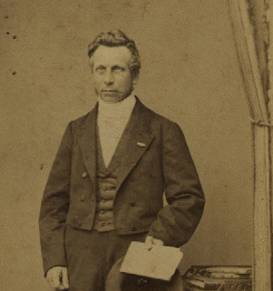

Kierkegaard’s mantle → philosophy of science

**objektiveringsloven** — the law of objectification

> there is no object without a corresponding act of objectification

Against Kant’s *fixed* critical boundary: the line between subject and object is renegotiated in every act of cognition

## Nielsen: one substrate, many objectifications

the same $X$ yields different objects under different frames:

$X \;\longrightarrow\; O_A,\; O_B,\; O_C$

not a failure of objectivity — its very structure

Nielsen’s word for it: *Vexelvirkning* — **interaction**

the term Bohr will reach for in quantum measurement

## Harald Høffding (1843-1931)

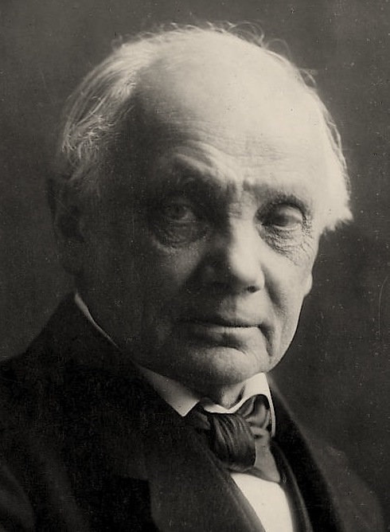

Høffding inherits Nielsen’s law almost word for word.

> The subject is the Archimedean point in the theory of cognition — the point from which existence cannot be moved, but only apprehended. And such a point must always be presupposed.

No pure object, no pure subject — only $S_o$ and $O_s$. Neither can be eliminated.

## Høffding: the case Bas does not name

Van Fraassen looks outward — art, the spiritual journey, the *other* person.

I would add the case where non-objectification is *structural*: introspection.

> I think that I think of my thinking … and divide myself into an infinitely retreating succession of egos observing each other (Poul Møller, *Tale of a Danish Student*, 1843)

The subject cannot be both the detached observer *and* part of the object. The cut can be moved — never eliminated.

## Høffding reads Einstein (1921)

The Putnam worry, fifty years early: must one observer be under an *illusion*?

> each observer has his own system of measurement, which is just as legitimate as another’s

Not the manifest image destroyed — the observer made necessary. No description without a describer.

And inquiry is *led ever further* — a *plus ultra* — rather than closing off. Knowledge carried beyond itself.

## Niels Bohr

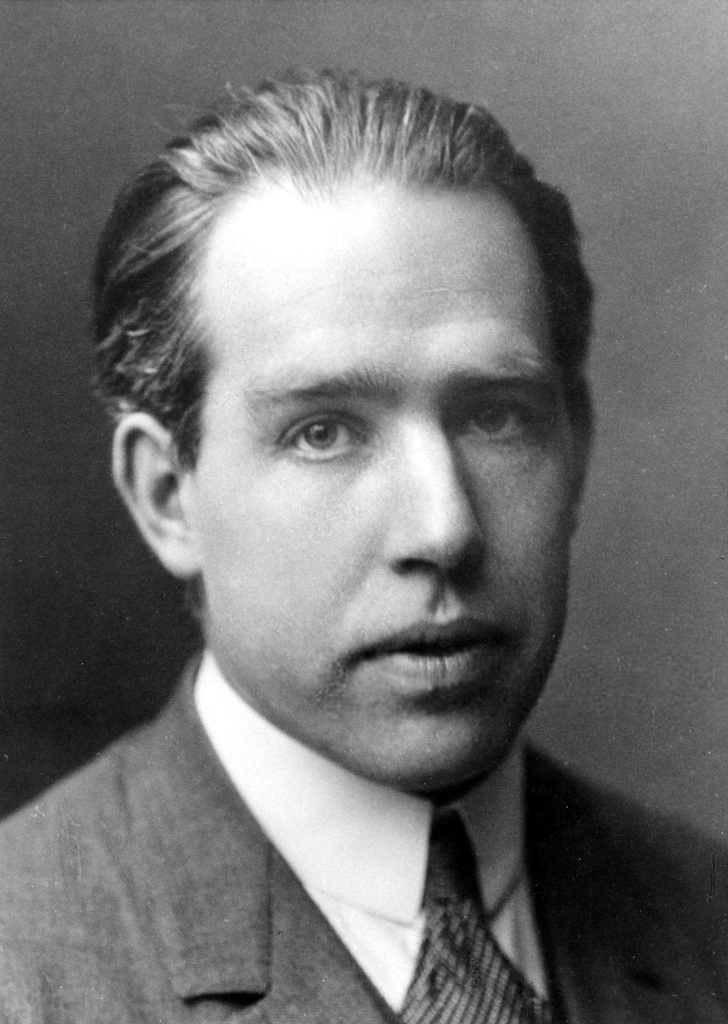

Høffding’s student — his chapter title becomes Bohr’s thesis:

> the relation between subject and object forms the core of the problem of knowledge

The epistemological lesson: to describe objectively, renounce the “description from nowhere.”

Every description splits the world into describer and described — and holds for the context that split creates.

## Why the describer cannot step outside

Because $\hbar \neq 0$, the describer is *entangled* with the described.

Like a journalist caught up in the protest she is covering —

her entanglement is what prevents a detached, objective account.

The clean separation of self from object is exactly what fails.

## Two roads to Bas

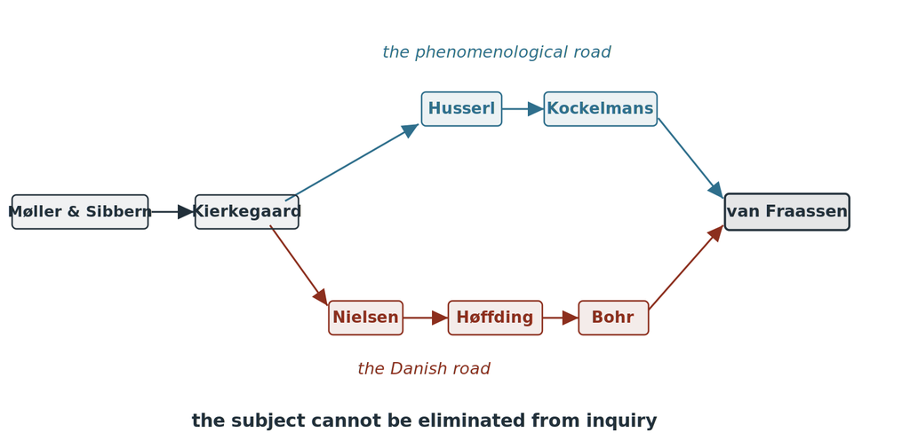

# Back to Bas’s mission

## Ich musste das Wissen aufheben

> Ich mußte also das Wissen aufheben, um zum Glauben Platz zu bekommen. (Kant, *Critique of Pure Reason*, Preface B xxx)

not “deny”, not “restrict” — aufheben: to carry knowledge beyond itself

One enters a *parenthesis* to know objectively — but is not finished until, through *double reflection*, the knowledge is brought home into a self and a life.

*Tilegne*: to appropriate, to make one’s own. *Wissen* is a moment, not the telos.

## What is the mission?

Hegel, Putnam: the progress of *Science*

Kierkegaard, van Fraassen: the personal telos of the individual human being, and science is one of the means.

Science is better when whole human beings do it. Bohr. Einstein. Schrödinger. Noether.

Like Høffding before him, Bas has prepared the ground — for the humans who will do science next.